# Effects of client type, age and gender on the frequency and length of trips

## by Wilfred Kotey

## Investigation Overview

In this investigation, I wanted to look at the time most trips were taken and how it was influenced by the clientele of the bike service. I also wanted to find the relationship between age and length of the trip and also the gender and the length of trip.

## Dataset Overview

The dataset contains 174952 rows and 21 columns for the Ford GoBike System in a bike-sharing system after 8460 data points were removed from the analysis due to missing information. The features explored included age, gender, number of trips and the duration of the trips.

## Days and time of day when most trips are taken by clientele

A clustered bar chart of hours and the trip counts with the different users shows which time the service was mostly used and by who. It shows the time of the day when the service had very high patronage. A heatmap also shows that there were a lot more subscribers on every day of the week as compared to casual users.

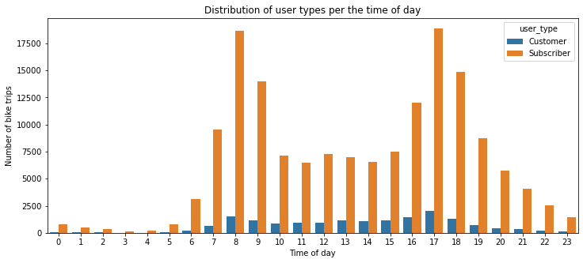

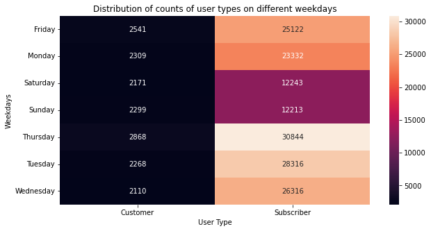

## Age and Length of the trip

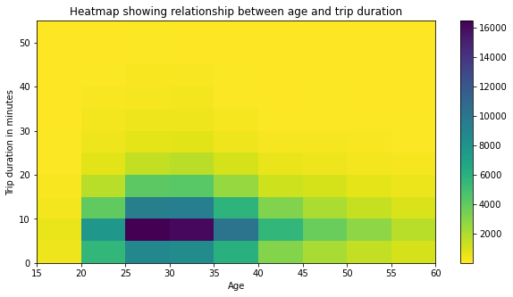

## Gender vs Length of trip

The relationship between gender and trip length is shown using a seaborn stripplot with different colours to identify the different genders. This clearly gives an indication of the genders and the duration of their trips. It was observed that both males and females took longer trips than others and that the trip duration for both males and females was not that different after removing the outliers.

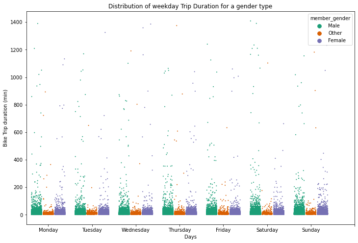

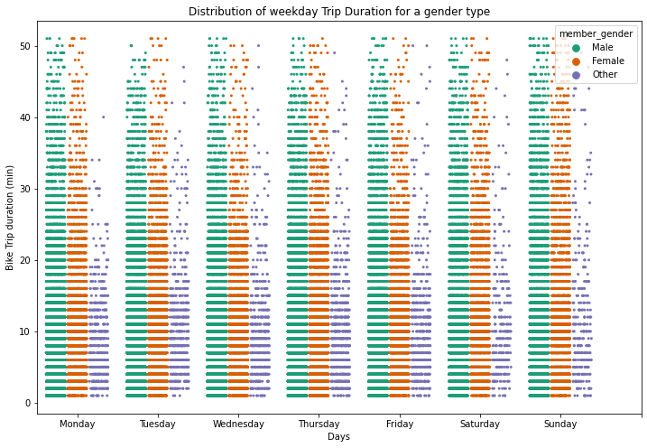